# Analysis of Ribosomal rRNA Fragments (ARF) — Use Cases

```r
# Load ARF from the cloned repository (working directory = repo root)
if (requireNamespace("devtools", quietly = TRUE)) {
  devtools::load_all(".")
} else {
  library(ARF)
}
```

```r
for (d in c(
  "testrun/mouse_drip",
  "testrun/mouse_dric",
  "testrun/ecoli",
  "testrun/ecoli/dricARF",
  "testrun/arabidopsis",
  "testrun/arabidopsis/dripARF",
  "testrun/arabidopsis/dricARF"
)) dir.create(d, showWarnings = FALSE, recursive = TRUE)
```

This notebook provides working use-case examples for the **ARF** pipeline. All paths are relative to the repository root.

# Built-in organisms — mouse (fully runnable)

The repository includes mouse Ribo-seq test data aligned to the built-in mouse rRNA sequences. No PDB download or custom structural setup is needed.

[output not shown]

[output not shown]

[output not shown]

[output not shown]

[output not shown]

[output not shown]

[output not shown]

[output not shown]

[output not shown]

[output not shown]

[output not shown]

[output not shown]

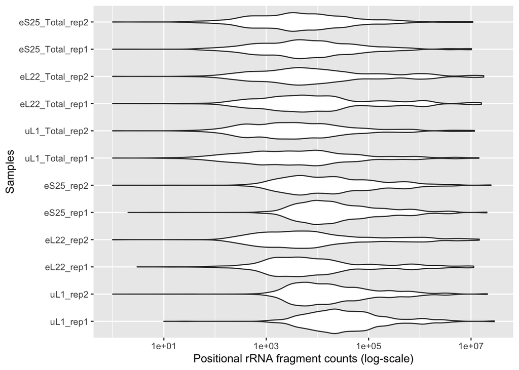

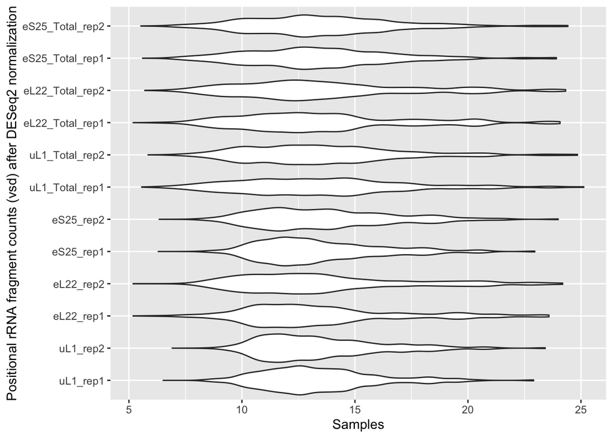

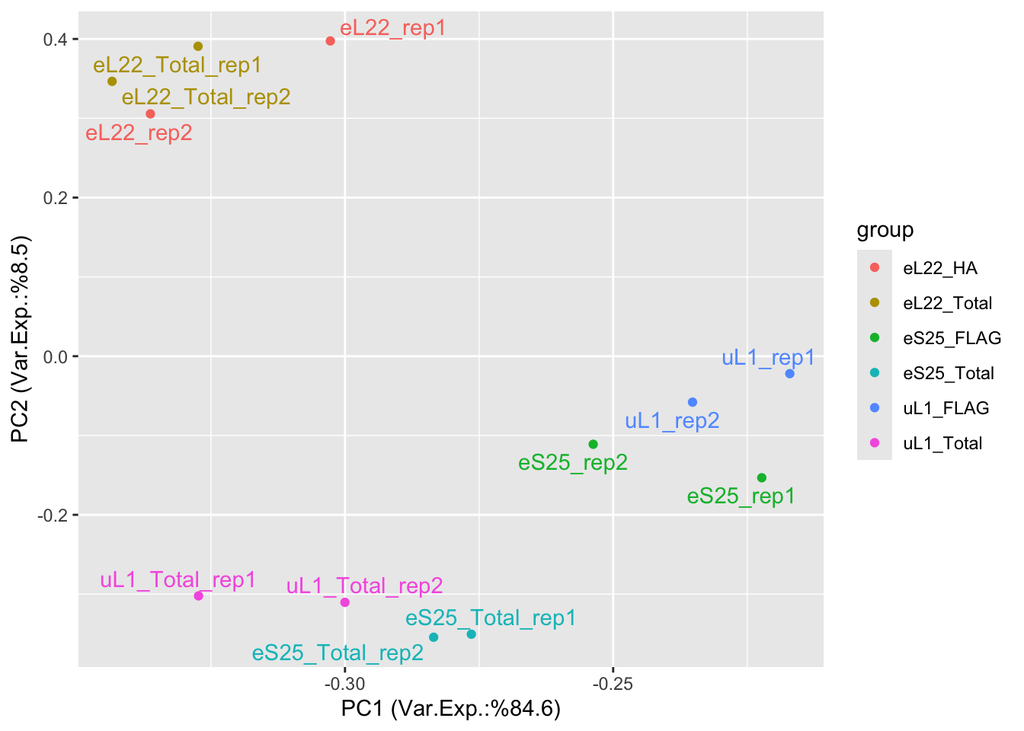

```
##
## Running ssRPSEA normalization...
```

```
## Estimating ssGSEA scores for 80 gene sets.
## [1] "Calculating ranks..."
```

[output not shown]

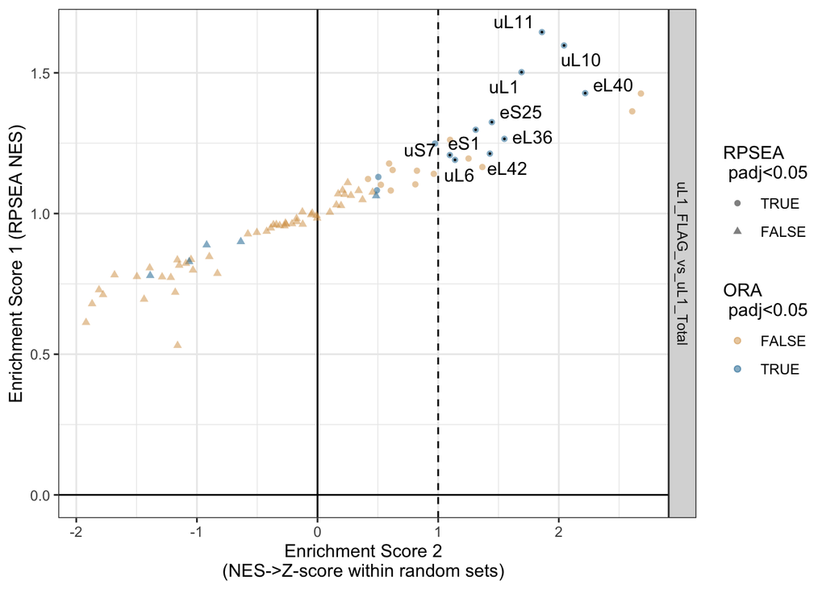

```r
dripARF_results <- ARF::dripARF(
  samplesFile    = "test_data/Rpl10aRps25Rpl22_samples_mouse.tsv",
  rRNAs_fasta    = "rRNAs/mouse_rRNAs.fa",
  organism       = "mm",
  compare        = "group",
  comparisons    = list(c("uL1_FLAG", "uL1_Total")),
  QCplot         = TRUE,
  ssRPSEAplots   = FALSE,
  targetDir      = "testrun/mouse_drip"
)
```

```r
head(dripARF_results[, c("comp","Description","RPSEA.NES","RPSEA.NES_randZ","RPSEA.padj","ORA.padj")])
```

```
##                    comp Description RPSEA.NES RPSEA.NES_randZ   RPSEA.padj
## 1 uL1_FLAG_vs_uL1_Total        uL11  1.644840        1.860226 1.333333e-09
## 2 uL1_FLAG_vs_uL1_Total        uL10  1.597317        2.043410 1.333333e-09
## 3 uL1_FLAG_vs_uL1_Total         uL1  1.502475        1.691145 1.333333e-09
## 4 uL1_FLAG_vs_uL1_Total        eL40  1.427826        2.218882 1.333333e-09
## 5 uL1_FLAG_vs_uL1_Total        eL15  1.426505        2.680698 1.333333e-09
## 6 uL1_FLAG_vs_uL1_Total   uL16.like  1.363224        2.608559 1.333333e-09
##       ORA.padj
## 1 1.580057e-07
## 2 5.247218e-17
## 3 2.935204e-04
## 4 2.848962e-05
## 5 1.940707e-01
## 6 1.000000e+00
```

[output not shown]

[output not shown]

[output not shown]

[output not shown]

[output not shown]

[output not shown]

[output not shown]

[output not shown]

[output not shown]

[output not shown]

[output not shown]

[output not shown]

```
##
## Running ssRPSEA normalization...
```

```
## Estimating ssGSEA scores for 89 gene sets.
## [1] "Calculating ranks..."
```

[output not shown]

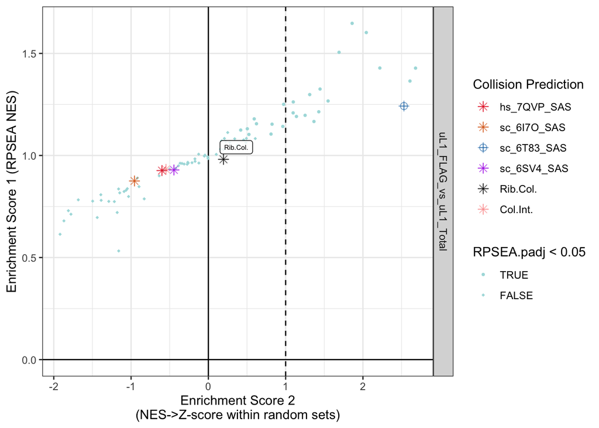

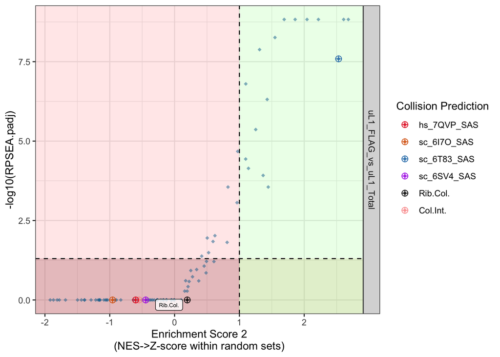

```r
dricARF_results <- ARF::dricARF(
  samplesFile  = "test_data/Rpl10aRps25Rpl22_samples_mouse.tsv",
  rRNAs_fasta  = "rRNAs/mouse_rRNAs.fa",
  organism     = "mm",
  compare      = "group",
  comparisons  = list(c("uL1_FLAG", "uL1_Total")),
  QCplot       = FALSE,
  ssRPSEAplots = FALSE,
  targetDir    = "testrun/mouse_dric"
)
```

```r
head(dricARF_results[, c("comp","Description","RPSEA.NES","RPSEA.NES_randZ","RPSEA.padj","ORA.padj")])
```

```
##                    comp Description RPSEA.NES RPSEA.NES_randZ   RPSEA.padj
## 1 uL1_FLAG_vs_uL1_Total        uL11  1.647435        1.860226 1.483333e-09
## 2 uL1_FLAG_vs_uL1_Total        uL10  1.602323        2.043410 1.483333e-09
## 3 uL1_FLAG_vs_uL1_Total         uL1  1.505497        1.691145 1.483333e-09
## 4 uL1_FLAG_vs_uL1_Total        eL40  1.428544        2.218882 1.483333e-09
## 5 uL1_FLAG_vs_uL1_Total        eL15  1.427992        2.680698 1.483333e-09
## 6 uL1_FLAG_vs_uL1_Total   uL16.like  1.364645        2.608559 1.483333e-09
##       ORA.padj
## 1 1.757814e-07
## 2 5.837530e-17
## 3 3.265415e-04
## 4 3.169470e-05
## 5 2.159036e-01
## 6 1.000000e+00
```

# Custom organism — PDB in ARF database (E. coli, requires internet)

When the PDB ID is already in the ARF structural database (e.g. 6XZA for *E. coli*), no manual chain mapping is needed. The steps below download the PDB file (~50 MB), compute RP–rRNA distances, and generate GSEA sets ready for analysis.

```r
ecoli_outdir <- "testrun/ecoli"
dir.create(ecoli_outdir, showWarnings = FALSE, recursive = TRUE)
```

## Computing RP–rRNA distances: `ARF_parse_PDB_ribosome`

```r
RP_proximity_df <- ARF::ARF_parse_PDB_ribosome(
  species            = "ec",
  PDBid              = "6XZA",
  download_directory = ecoli_outdir,
  out_prefix         = file.path(ecoli_outdir, "Ribosome.3D")
)
```

```
##    PDB has ALT records, taking A only, rm.alt=TRUE
```

[output not shown]

```r
head(RP_proximity_df[, 1:8])
```

```
##                rRNA resno     bL17     bL19     bL20     bL21     bL25     bL27
## rRNA_16S_1 rRNA_16S     1 124.6766 84.05763 167.6931 166.7970 157.9360 141.4937
## rRNA_16S_2 rRNA_16S     2 121.3063 81.04034 164.6928 164.0205 156.0743 139.3862
## rRNA_16S_3 rRNA_16S     3 118.5931 79.10021 162.2417 161.6628 154.9880 137.4868
## rRNA_16S_4 rRNA_16S     4 115.8100 76.37127 154.7506 152.8312 146.7143 126.4935
## rRNA_16S_5 rRNA_16S     5 123.7808 83.46115 161.1521 158.3869 149.4530 129.7835
## rRNA_16S_6 rRNA_16S     6 123.8482 83.87247 159.3839 156.0171 146.2595 126.0625
```

The rRNA names in this FASTA (used as keys in `rRNA_pairs`):

```r
ecoli_rRNAs_fasta <- file.path(ecoli_outdir, "6XZA.rRNAs.fasta")
(ecoli_rRNA_names <- names(Biostrings::readBStringSet(ecoli_rRNAs_fasta)))
```

```
## [1] "rRNA_16S" "rRNA_23S" "rRNA_5S"
```

## Liftover distances to study organism: `ARF_convert_Ribo3D_pos`

For a same-species run the source and target FASTAs are identical; the function still lifts coordinates through alignment, confirming no positions are lost.

```r
LO.RP_proximity_df <- ARF::ARF_convert_Ribo3D_pos(
  source_distance_file = file.path(ecoli_outdir, "Ribosome.3D.6XZA.ARF.minimum_distances.csv"),
  source_rRNAs_fasta   = ecoli_rRNAs_fasta,
  target_species       = "ec",
  target_rRNAs_fasta   = ecoli_rRNAs_fasta,
  rRNA_pairs           = list(
    c("rRNA_16S", "rRNA_16S"),
    c("rRNA_23S", "rRNA_23S"),
    c("rRNA_5S",  "rRNA_5S")
  ),
  source_positions = NULL,
  source_sets      = NULL,
  type             = "distances"
)
```

```
## use default substitution matrix
## use default substitution matrix
## use default substitution matrix
```

```r
head(LO.RP_proximity_df[, 1:8])
```

```
##                rRNA resno     bL17     bL19     bL20     bL21     bL25     bL27
## rRNA_16S_1 rRNA_16S     1 124.6766 84.05763 167.6931 166.7970 157.9360 141.4937
## rRNA_16S_2 rRNA_16S     2 121.3063 81.04034 164.6928 164.0205 156.0743 139.3862
## rRNA_16S_3 rRNA_16S     3 118.5931 79.10021 162.2417 161.6628 154.9880 137.4868
## rRNA_16S_4 rRNA_16S     4 115.8100 76.37127 154.7506 152.8312 146.7143 126.4935
## rRNA_16S_5 rRNA_16S     5 123.7808 83.46115 161.1521 158.3869 149.4530 129.7835
## rRNA_16S_6 rRNA_16S     6 123.8482 83.87247 159.3839 156.0171 146.2595 126.0625
```

## Generating RP proximity sets: `dripARF_get_RP_proximity_sets`

```r
gsea_sets_RP <- ARF::dripARF_get_RP_proximity_sets(
  RP_proximity_df   = LO.RP_proximity_df,
  additional_RPcols = c(),
  rRNAs_fasta       = ecoli_rRNAs_fasta,
  thresholds        = NULL,
  cap_added_RPcols  = FALSE
)

head(gsea_sets_RP)
```

```
##    ont          gene
## 1 bL17  rRNA_23S_489
## 2 bL17  rRNA_23S_491
## 3 bL17  rRNA_23S_492
## 4 bL17 rRNA_23S_1266
## 5 bL17 rRNA_23S_1267
## 6 bL17 rRNA_23S_1268
```

## Generating collision sets: `dricARF_liftover_collision_sets`

The pair list maps built-in collision-set rRNA keys (“16S”, “28S”, “5S”) to the target organism’s rRNA names as they appear in the study FASTA.

```r
gsea_sets_Collision <- ARF::dricARF_liftover_collision_sets(
  target_species     = "ec",
  target_rRNAs_fasta = ecoli_rRNAs_fasta,
  rRNA_pairs         = list(
    c("16S", "rRNA_16S"),
    c("28S", "rRNA_23S"),
    c("5S",  "rRNA_5S")
  )
)
```

```
## use default substitution matrix
## use default substitution matrix
## use default substitution matrix
## use default substitution matrix
## use default substitution matrix
## use default substitution matrix
```

```r
tail(gsea_sets_Collision)
```

```
##                    ont          gene
## 179195 Rand99_Rib.Col. rRNA_23S_2668
## 179196 Rand99_Rib.Col. rRNA_23S_2669
## 179197 Rand99_Rib.Col. rRNA_23S_2670
## 179198 Rand99_Rib.Col. rRNA_23S_2713
## 179199 Rand99_Rib.Col. rRNA_23S_2839
## 179200 Rand99_Rib.Col. rRNA_23S_2840
```

## Running dripARF / dricARF

The samples file should look like:

| sampleName | bedGraphFile | group |
| --- | --- | --- |
| RIBO_pH7.6_1 | path/to/SRR22447291.bedGraph | RIBO_pH7.6 |
| RIBO_pH5.8_1 | path/to/SRR22447288.bedGraph | RIBO_pH5.8 |
| RIBO_pH4.4_1 | path/to/SRR22447286.bedGraph | RIBO_pH4.4 |

[output not shown]

[output not shown]

[output not shown]

[output not shown]

[output not shown]

[output not shown]

[output not shown]

[output not shown]

[output not shown]

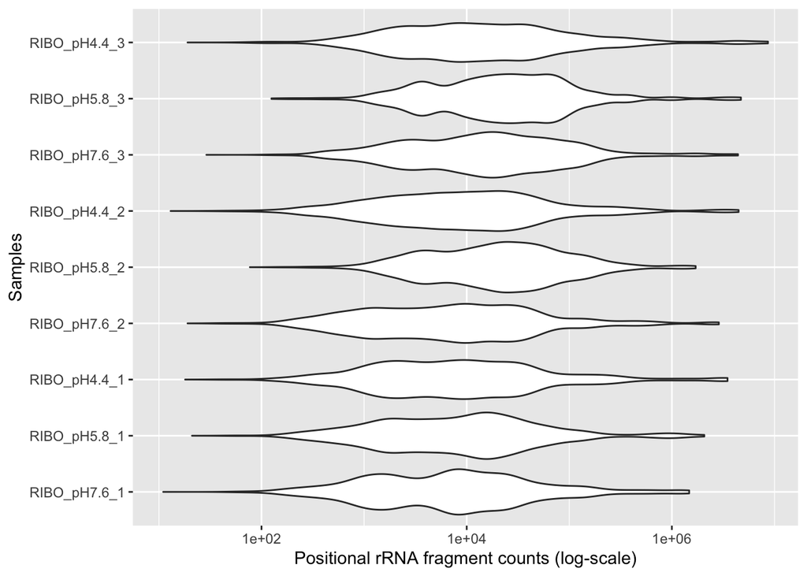

```
##
## out of 4563 with nonzero total read count
## adjusted p-value < 0.1
## LFC > 0 (up)       : 49, 1.1%
## LFC < 0 (down)     : 81, 1.8%
## outliers [1]       : 0, 0%
## low counts [2]     : 0, 0%
## (mean count < 96)
## [1] see 'cooksCutoff' argument of ?results
## [2] see 'independentFiltering' argument of ?results
##
## NULL
```

```
##
## out of 4563 with nonzero total read count
## adjusted p-value < 0.1
## LFC > 0 (up)       : 239, 5.2%
## LFC < 0 (down)     : 370, 8.1%
## outliers [1]       : 0, 0%
## low counts [2]     : 0, 0%
## (mean count < 96)
## [1] see 'cooksCutoff' argument of ?results
## [2] see 'independentFiltering' argument of ?results
##
## NULL
```

```
##
## out of 4563 with nonzero total read count
## adjusted p-value < 0.1
## LFC > 0 (up)       : 268, 5.9%
## LFC < 0 (down)     : 538, 12%
## outliers [1]       : 0, 0%
## low counts [2]     : 0, 0%
## (mean count < 96)
## [1] see 'cooksCutoff' argument of ?results
## [2] see 'independentFiltering' argument of ?results
##
## NULL
```

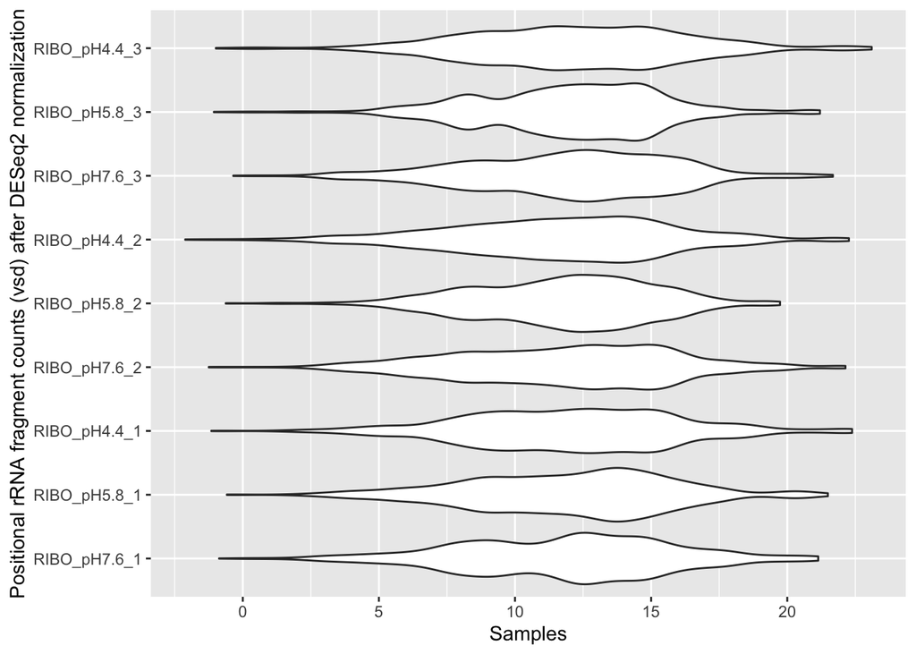

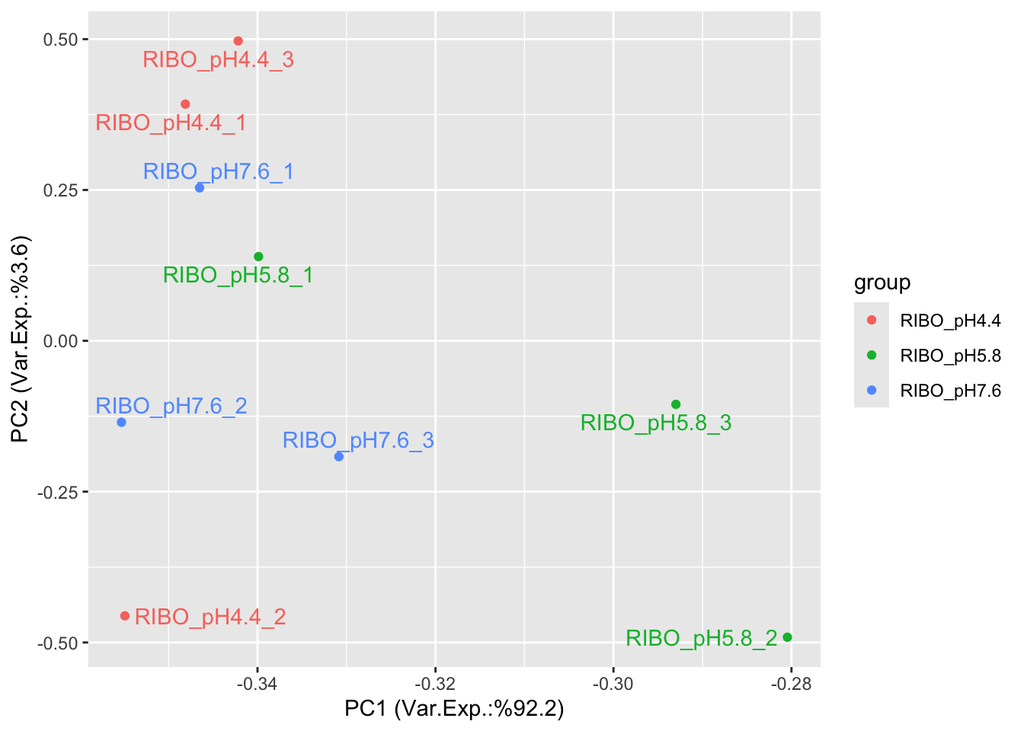

```
##
## Running ssRPSEA normalization...
```

```
## Estimating ssGSEA scores for 58 gene sets.
## [1] "Calculating ranks..."
```

[output not shown]

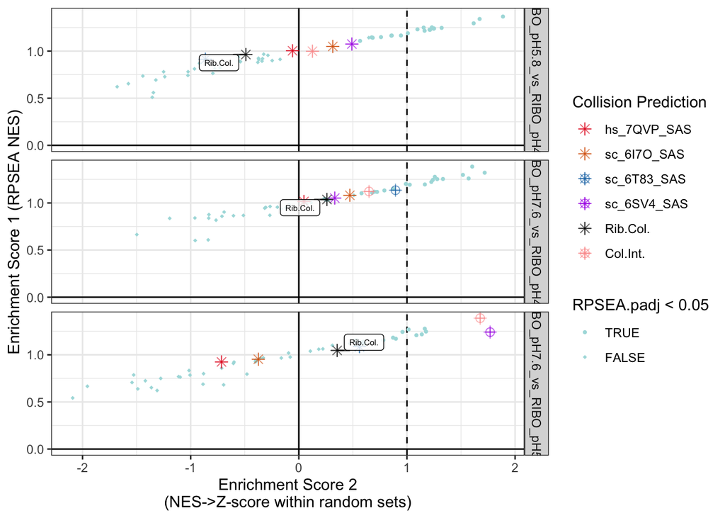

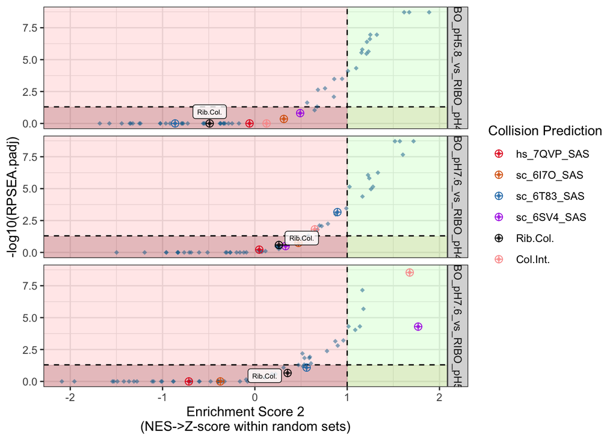

```r
dricARF_results <- ARF::dricARF(
  samplesFile         = "test_data/Escherichia_PRJNA906596/riboseq/samples.tsv",
  rRNAs_fasta         = ecoli_rRNAs_fasta,
  samples_df          = NULL,
  organism            = NULL,
  compare             = "group",
  QCplot              = TRUE,
  targetDir           = file.path(ecoli_outdir, "dricARF"),
  comparisons         = NULL,
  exclude             = NULL,
  ssRPSEAplots        = TRUE,
  gsea_sets_RP        = gsea_sets_RP,
  RP_proximity_df     = LO.RP_proximity_df,
  gsea_sets_Collision = gsea_sets_Collision
)
```

```r
head(dricARF_results)
```

```
##                       comp      Description ORA.overlap ORA.setSize
## 1 RIBO_pH7.6_vs_RIBO_pH5.8 hs_7QVP_Col.Int.          20         104
## 2 RIBO_pH7.6_vs_RIBO_pH5.8         Col.Int.          21         192
## 3 RIBO_pH7.6_vs_RIBO_pH5.8 sc_6T83_Col.Int.           6         110
## 4 RIBO_pH7.6_vs_RIBO_pH5.8             bS20          21         227
## 5 RIBO_pH7.6_vs_RIBO_pH5.8             uL24           0         158
## 6 RIBO_pH7.6_vs_RIBO_pH5.8 sc_6I7O_Col.Int.           5         137
##       ORA.padj        ORA.p RPSEA.NES RPSEA.NES_randZ   RPSEA.padj   RPSEA.pval
## 1 6.532619e-15 1.126314e-16  1.490572        2.119741 2.900000e-09 1.000000e-10
## 2 4.235513e-11 2.190783e-12  1.389064        1.677160 2.900000e-09 1.000000e-10
## 3 6.528712e-02 1.013076e-02  1.351827        1.514802 9.655704e-07 6.659106e-08
## 4 8.341527e-10 5.752778e-11  1.277427        1.164723 7.019744e-08 3.630902e-09
## 5 1.000000e+00 1.000000e+00  1.268821        1.015002 4.886503e-05 5.288326e-06
## 6 3.885584e-01 8.039140e-02  1.268808        1.152832 4.886503e-05 6.670877e-06
##        RPSEA.q ssRPSEA.weight weighted.RPSEA.NES_randZ C1.avg.read.c
## 1 1.255740e-09     0.03052354               0.06470202     276186.71
## 2 1.255740e-09     0.07923059               0.13288234      14054.54
## 3 4.857520e-07     0.42643341               0.64596205      60608.56
## 4 3.483902e-08     0.43109041               0.50210090      12198.04
## 5 2.586859e-05     0.30327736               0.30782727      60924.66
## 6 3.200400e-05     0.41115999               0.47399836      49098.18
##   C2.avg.read.c
## 1     155690.37
## 2      12269.39
## 3      49067.40
## 4      11626.46
## 5      52657.65
## 6      39360.97
```

# Custom organism — PDB not in ARF database (Arabidopsis)

When the PDB ID is not in the ARF structural database (e.g. 8B2L for *Nicotiana tabacum* / *Arabidopsis*), chain names must be mapped manually via a conversion table before distances can be computed. The rRNA sequences can be extracted directly from the RCSB FASTA bundled in `test_data/`, enabling collision-set liftover without the full structural pipeline.

> **NB:** Protein chain mapping is not automated due to inconsistencies across PDB files. Chain names and IDs differ from structure to structure.

## Extracting rRNA sequences from the PDB FASTA

The RCSB FASTA for 8B2L is included in `test_data/`. rRNA chains are identified by their description field and renamed to the standard `rRNA_XS` convention.

```r
at_outdir <- "testrun/arabidopsis"
dir.create(at_outdir, showWarnings = FALSE, recursive = TRUE)

raw_fasta  <- Biostrings::readBStringSet("test_data/rcsb_pdb_8B2L.fasta")
rRNA_idx   <- grepl("rRNA", names(raw_fasta), ignore.case = TRUE)
rRNA_seqs  <- raw_fasta[rRNA_idx]

# Rename: "...| 18S rRNA |..." → "rRNA_18S"
names(rRNA_seqs) <- sub(".*\\|([0-9.]+S) rRNA\\|.*", "rRNA_\\1", names(rRNA_seqs))

at_rRNAs_fasta <- file.path(at_outdir, "8B2L_rRNAs.fasta")
Biostrings::writeXStringSet(rRNA_seqs, at_rRNAs_fasta)

names(rRNA_seqs)
```

```
## [1] "rRNA_18S"  "rRNA_5.8S" "rRNA_25S"  "rRNA_5S"
```

## Generating collision sets: `dricARF_liftover_collision_sets`

With the rRNA FASTA available, collision-set liftover from human/yeast to the target organism runs without requiring the full structural pipeline.

```r
at_gsea_sets_Collision <- ARF::dricARF_liftover_collision_sets(
  target_species     = "AT",
  target_rRNAs_fasta = at_rRNAs_fasta,
  rRNA_pairs         = list(
    c("18S", "rRNA_18S"),
    c("25S", "rRNA_25S"),
    c("5S",  "rRNA_5S")
  )
)
```

```
## use default substitution matrix
## use default substitution matrix
## use default substitution matrix
## use default substitution matrix
## use default substitution matrix
## use default substitution matrix
```

```r
tail(at_gsea_sets_Collision)
```

[output not shown]

## Building a conversion table for protein chains (requires nomenclature data)

To compute RP–rRNA distances via `ARF_parse_PDB_ribosome`, protein chains must be mapped to standard RP names. This requires the organism to be present in `data-raw/ALL_PDB_RPS_edited.csv`. For 8B2L (*Nicotiana tabacum*) this entry is not yet in the database and must be added manually.

```r
conversion_table_generator <- function(rRNAs_file, organism = NULL,
                                       ALL_PDB_RPS_edited_file = "data-raw/ALL_PDB_RPS_edited.csv") {
  rRNA_seq_set <- Biostrings::readBStringSet(rRNAs_file)

  conversion_table <- as.data.frame(rRNA_seq_set@ranges) |>
    dplyr::mutate(
      ID      = sub("\\|.*", "", names),
      RP_name = sub(".*\\]\\|(.*)\\|.*", "\\1", names),
      chainID = paste0(sub(".*\\|(.*)\\]\\|.*", "\\1", names), "]")
    ) |>
    dplyr::mutate(
      RP_name = ifelse(
        grepl("protein|factor|initiator", RP_name),
        sapply(strsplit(RP_name, " "), function(x) x[length(x)]),
        sapply(strsplit(RP_name, " "), function(x) x[1])
      ),
      chainID = gsub("^Chain.*auth |\\]", "", chainID)
    )

  all_pdb_rps <- read.table(ALL_PDB_RPS_edited_file, sep = ",", header = TRUE)

  # Try exact organism match first
  organism_rp_df <- if (!is.null(organism))
    dplyr::filter(all_pdb_rps, organism == !!organism)
  else
    data.frame()

  # Fall back to the organism with the most overlapping RP names
  if (nrow(organism_rp_df) == 0) {
    protein_names <- conversion_table$RP_name[!grepl("rRNA", conversion_table$RP_name,
                                                      ignore.case = TRUE)]
    match_counts <- all_pdb_rps |>
      dplyr::group_by(organism) |>
      dplyr::summarize(n_match = sum(RPname %in% protein_names), .groups = "drop") |>
      dplyr::arrange(dplyr::desc(n_match))
    best_organism <- match_counts$organism[1]
    message(if (!is.null(organism)) paste0("Organism '", organism, "' not found. ") else "",
            "Using '", best_organism, "' as closest match (",
            match_counts$n_match[1], " overlapping RP names).")
    organism_rp_df <- dplyr::filter(all_pdb_rps, organism == best_organism)
  }

  organism_rp_df <- organism_rp_df |>
    dplyr::mutate(
      RPname = ifelse(grepl("rRNA", RPname), stringr::str_extract(RPname, "[0-9]+S"), RPname)
    )

  protein_rows <- dplyr::left_join(organism_rp_df[, c("RPname", "RP_new")], conversion_table,
                                   by = dplyr::join_by(RPname == RP_name)) |>
    dplyr::mutate(RP_name = RPname,
                  RP_new  = dplyr::coalesce(RP_new, RP_name)) |>
    dplyr::filter(!is.na(chainID)) |>
    dplyr::select(ID, RP_name, RP_new, chainID)

  rRNA_rows <- conversion_table |>
    dplyr::filter(grepl("rRNA", RP_name, ignore.case = TRUE)) |>
    dplyr::mutate(RP_new = RP_name) |>
    dplyr::select(ID, RP_name, RP_new, chainID)

  rbind(protein_rows, rRNA_rows)
}

final_conversion_df <- conversion_table_generator(
  rRNAs_file = "test_data/rcsb_pdb_8B2L.fasta",
  organism   = "Nicotiana tabacum"
) |> dplyr::distinct()

head(final_conversion_df)
```

## Computing distances and RP proximity sets

```r
RP_proximity_df <- ARF::ARF_parse_PDB_ribosome(
  species                      = "AT",
  PDBid                        = "8B2L",
  download_directory           = at_outdir,
  out_prefix                   = file.path(at_outdir, "Ribosome.3D"),
  PDB_chains_2_RP_nomenclature = final_conversion_df
)

head(RP_proximity_df[, 1:8])
```

```r
LO.RP_proximity_df <- ARF::ARF_convert_Ribo3D_pos(
  source_distance_file = file.path(at_outdir, "Ribosome.3D.8B2L.ARF.minimum_distances.csv"),
  source_rRNAs_fasta   = file.path(at_outdir, "8B2L.rRNAs.fasta"),
  target_species       = "AT",
  target_rRNAs_fasta   = at_rRNAs_fasta,
  rRNA_pairs           = list(
    c("rRNA_18S", "rRNA_18S"),
    c("rRNA_25S", "rRNA_25S"),
    c("rRNA_5S",  "rRNA_5S")
  ),
  source_positions = NULL,
  source_sets      = NULL,
  type             = "distances"
)

gsea_sets_RP <- ARF::dripARF_get_RP_proximity_sets(
  RP_proximity_df   = LO.RP_proximity_df,
  additional_RPcols = c(),
  rRNAs_fasta       = at_rRNAs_fasta,
  thresholds        = NULL,
  cap_added_RPcols  = FALSE
)
```

## Running dripARF / dricARF

```r
# gsea_sets_RP and LO.RP_proximity_df require ARF_parse_PDB_ribosome to have run first
dripARF_results <- ARF::dripARF(
  samplesFile     = "test_data/Arabidopsis_PRJNA925168/riboseq/samples.tsv",
  rRNAs_fasta     = at_rRNAs_fasta,
  organism        = "AT",
  compare         = "group",
  QCplot          = TRUE,
  targetDir       = file.path(at_outdir, "dripARF"),
  ssRPSEAplots    = TRUE,
  gsea_sets_RP    = gsea_sets_RP,
  RP_proximity_df = LO.RP_proximity_df
)

dricARF_results <- ARF::dricARF(
  samplesFile         = "test_data/Arabidopsis_PRJNA925168/riboseq/samples.tsv",
  rRNAs_fasta         = at_rRNAs_fasta,
  organism            = "AT",
  compare             = "group",
  QCplot              = TRUE,
  targetDir           = file.path(at_outdir, "dricARF"),
  ssRPSEAplots        = TRUE,
  gsea_sets_RP        = gsea_sets_RP,
  RP_proximity_df     = LO.RP_proximity_df,
  gsea_sets_Collision = at_gsea_sets_Collision
)

head(dricARF_results)
```